# BME 4550 Assignment 7

# second chapter, second exercises

```r
library(tissuesGeneExpression)
data(tissuesGeneExpression)
```

## 1. What is the correlation between the first column of U and m?

### The correlation is -0.9999998

```r
s = svd(e)
m = rowMeans(e)
cor(s$u[,1],m)
```

```
## [1] -0.9999998
```

## 2. Which of the following gives us the same as diag(s$d)%*%t(s$v) ?

### s$d * t(s$v) outputs the same thing as diag(s$d)%*%t(s$v).

```r
 newmeans = rnorm(nrow(e)) ##random values we will add to create new means
 newe = e+newmeans ##we change the means
 sqrt(crossprod(e[,3]-e[,45]))
```

```
##          [,1]
## [1,] 152.5662
```

```r
 sqrt(crossprod(newe[,3]-newe[,45]))
```

```
##          [,1]
## [1,] 152.5662
```

```r
y = e - rowMeans(e)
s = svd(y)

resid = y - s$u %*% diag(s$d) %*% t(s$v)
max(abs(resid))
```

```
## [1] 1.188383e-12
```

```r
x=matrix(rep(c(1,2),each=5),5,2)
x*c(1:5)
```

```
##      [,1] [,2]
## [1,]    1    2
## [2,]    2    4
## [3,]    3    6
## [4,]    4    8
## [5,]    5   10
```

```r
sweep(x,1,1:5,"*")
```

```
##      [,1] [,2]
## [1,]    1    2
## [2,]    2    4
## [3,]    3    6
## [4,]    4    8
## [5,]    5   10
```

```r
diag(s$d)%*%t(s$v)
```

[output not shown]

[output cut: 9105 more lines]

```r
s$d * t(s$v)
```

[output not shown]

[output cut: 9105 more lines]

## 3. If we define vd = t(s$d * t(s$v)), then which of the following is not the same UDV ?

```r
z = s$d * t(s$v)

sqrt(crossprod(e[,3]-e[,45]))
```

```
##          [,1]
## [1,] 152.5662
```

```r
sqrt(crossprod(y[,3]-y[,45]))
```

```
##          [,1]
## [1,] 152.5662
```

```r
sqrt(crossprod(z[,3]-z[,45]))
```

```
##          [,1]
## [1,] 152.5662
```

## 4. What is the difference, in absolute value, between the actual distance: sqrt(crossprod(e[,3]-e[,45])) and the approximation using only two dimensions of z ?

```r
realdistance = sqrt(crossprod(e[,3]-e[,45]))
approxdistance = sqrt(crossprod(z[1:2,3]-z[1:2,45]))
abs(realdistance - approxdistance)
```

```
##          [,1]
## [1,] 40.62416
```

40.62416

## 5. How many dimensions do we need to use for the approximation in exercise 4 to be within 10%?

```r
ks = 1:189
realdistance = sqrt(crossprod(e[,3]-e[,45]))
approxdistances = sapply(ks,function(k){
    sqrt(crossprod(z[1:k,3,drop=FALSE]-z[1:k,45,drop=FALSE] ))
  })
percentdiff = 100*abs(approxdistances - realdistance)/realdistance
```

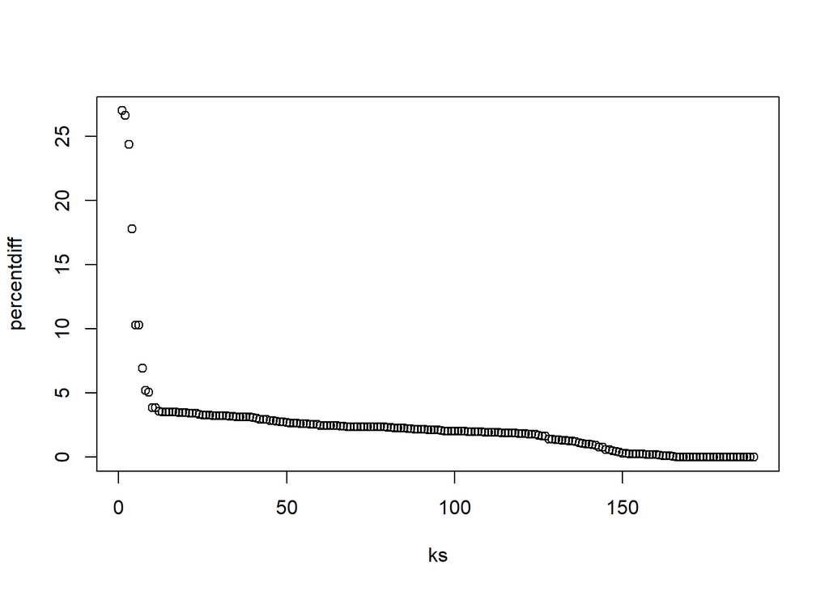

```r
plot(ks,percentdiff) ##take a look
```

```r
min(ks[which(percentdiff < 10)])
```

```
## [1] 7
```

7 dimensions

## 6. Compute distances between sample 3 and all other samples.

```r
distances = sqrt(apply(e[,-3]-e[,3],2,crossprod))
```

## 7. Recompute this distance using the 2 dimensional approximation. What is the Spearman correlation between this approximate distance and the actual distance?

### The Spearman correlation between the approximate distance and the actual distance is 0.8598592

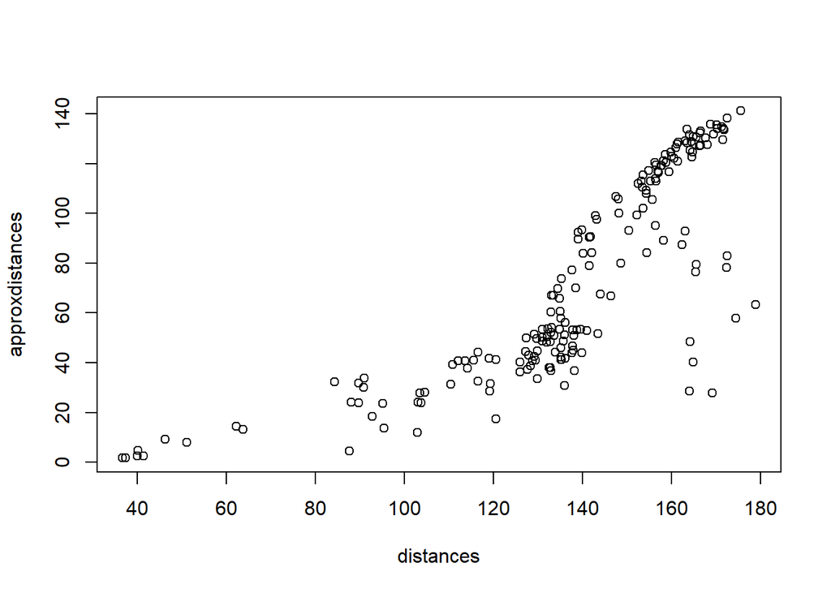

```r
approxdistances = sqrt(apply(z[1:2,-3]-z[1:2,3],2,crossprod))
plot(distances,approxdistances)
```

```r
cor(distances,approxdistances,method="spearman")
```

```
## [1] 0.8598592
```

# second chapter, third exercises

## 1. What is the absolute value of the correlation between the first dimension of z and the first dimension in mds?

### The absolute value of the correlation between the first dimension of z and the first dimension in mds is 0.04008834

```r
d = dist(t(e))
mds = cmdscale(d)
cor(mds[, 1], z[, 1])
```

```
## [1] 0.04008834
```

## 2. What is the absolute value of the correlation between the second dimension of z and the second dimension in mds?

### The absolute value of the correlation between the second dimension of z and thesecond dimension in mds is 0.02099933.

```r
d = dist(t(e))
mds = cmdscale(d)
cor(mds[, 2], z[, 2])
```

```
## [1] 0.02099933
```

```r
library(GSE5859Subset)
data(GSE5859Subset)
s = svd(geneExpression-rowMeans(geneExpression))
z = s$d * t(s$v)
```

## What is this max correlation?

### The max correlation is 0.6236858

```r
max(cor(sampleInfo$g,t(z)))
```

```
## [1] 0.6236858
```

## 5. Which dimension of z has the second highest correlation with the outcome sampleInfo$group?

### The dimension of z which has the second highest correlation with the outcome sampleInfo$group is dimension 6.

```r
which.max(cor(sampleInfo$g,t(z))[-1]) + 1
```

```
## [1] 6
```

```r
sampleInfo$date
```

```
##  [1] "2005-06-23" "2005-06-27" "2005-06-27" "2005-10-28" "2005-10-07"
##  [6] "2005-10-07" "2005-10-28" "2005-10-07" "2005-10-07" "2005-10-07"
## [11] "2005-10-07" "2005-10-07" "2005-06-27" "2005-06-23" "2005-06-10"
## [16] "2005-06-23" "2005-06-23" "2005-06-27" "2005-06-23" "2005-06-27"
## [21] "2005-06-23" "2005-10-07" "2005-10-07" "2005-10-07"
```

```r
month = format( sampleInfo$date, "%m")
month = factor( month)
which.max(cor( as.numeric(month), t(z)))
```

```
## [1] 1
```

## 7. What is this correlation?

### The correlation of the dimension of z and the month is 0.8297915.

```r
month = format( sampleInfo$date, "%m")
month = factor( month)
max(cor( as.numeric(month), t(z)))
```

```
## [1] 0.8297915
```

## 8. Which chromosome looks different from the rest? Copy and paste the name as it appears in geneAnnotation.

## Based on the results, my guess as to what sampleInfo$group represents is chrY.

```r
table(sampleInfo$g,month)
```

```
##    month
##     06 10
##   0  9  3
##   1  3  9
```

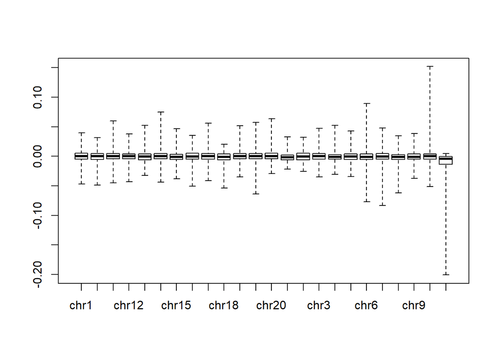

```r
result = split(s$u[,6],geneAnnotation$CHR)
result = result[ which(names(result)!="chrUn") ]
boxplot(result,range=0)
```

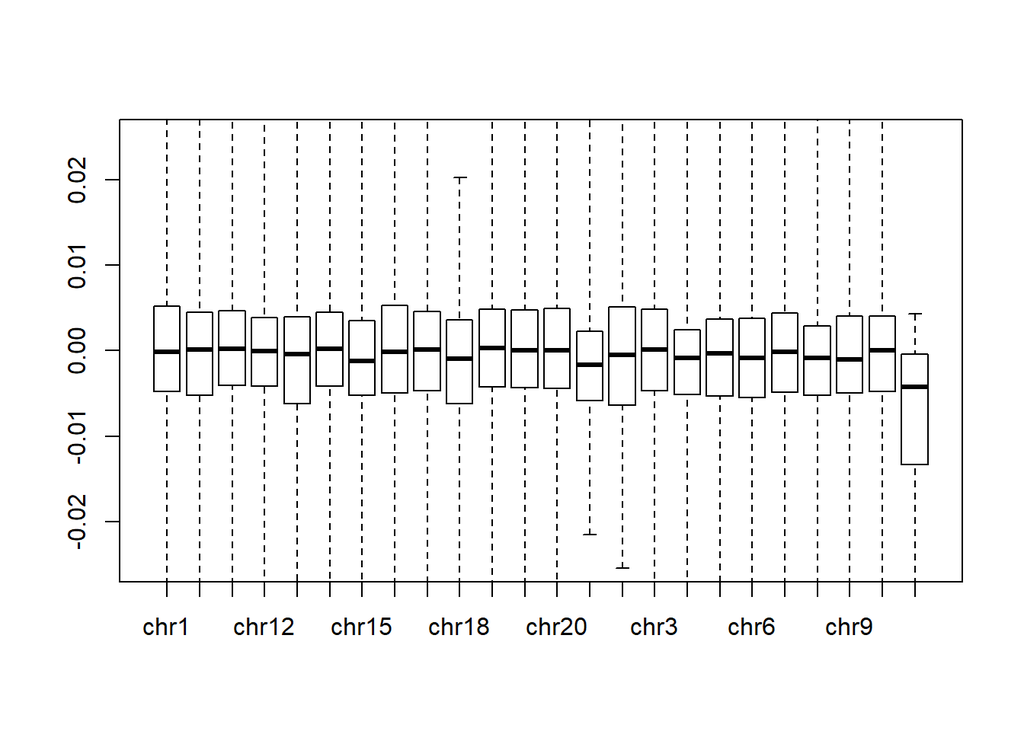

```r
boxplot(result,range=0,ylim=c(-0.025,0.025))
```

```r
medians = sapply(result,median)
names(result)[ which.max(abs(medians)) ]
```

```
## [1] "chrY"
```